# Анализ программы лояльности

Цель исследования - найти обоснование гипотезы о том, что программа лояльности стимулирует покупателей тратить больше.

Нам представлен датасет с информацией о продажах строительных материалов в магазинах ритейлера, участии пользователей в программе лояльности.

Основные шаги исследования:

**1. Загрузка и изучение информации**

Простая оценка имеющихся данных

**2. Преобразование данных**

Проверка данных на соответствие столбцов типам данных, наличие дублей, аномальных значений, корректность заполнения

**3. Исследовательский анализ**

- определить участников программы
- подсчитать количество участников программы
- подсчитать среднее количество заказов на участников программы и остальных покупателей
- подсчитать ср. чек участников программы и остальных покупателей
- подсчитать среднее количество предметов в чеке на участников программы и остальных покупателей
- определить возможные расчетные метрики и выполнить подсчет

**4. Проверка гипотез**

- Подбор статистического критерия
- Основная гипотеза: средний чек участников программы лояльности выше, чем у остальных покупателей
- Побочная гипотеза: среднее количество заказов в группе участников программы лояльности выше, чем у остальных покупателей

**5. Презентация выводов**

```python
import pandas as pd
from matplotlib import pyplot as plt
import numpy as np
import seaborn as sns
import statsmodels.api as sm
from scipy import stats as st
from scipy.stats import shapiro
from scipy.stats import mannwhitneyu
from datetime import datetime, timedelta
%matplotlib inline
import math
```

## Загрузка и изучение информации

Нам предоставлено 2 файла с которыми нам предстоит работать:

- retail_dataset.csv - содержит инфомарцию о клиентах и покупках
- product_codes.csv - содержит информацию о товарах

```python
#загрузка датасетов
try:
    retail_data = pd.read_csv("C:\\Users\\79991\\Desktop\\JupyterNotebooks\\Выпускнойпроект\\retail_dataset.csv")
    product_codes = pd.read_csv("C:\\Users\\79991\\Desktop\\JupyterNotebooks\\Выпускнойпроект\\product_codes.csv")
except:
    retail_data = pd.read_csv('/datasets/retail_dataset.csv')
    product_codes = pd.read_csv('/datasets/product_codes.csv')
```

Ознакомимся с содержимым файлов

```python
retail_data.info()
```

```
<class 'pandas.core.frame.DataFrame'>
RangeIndex: 105335 entries, 0 to 105334
Data columns (total 7 columns):
 #   Column           Non-Null Count   Dtype
---  ------           --------------   -----
 0   purchaseid       105335 non-null  object
 1   item_ID          105335 non-null  object
 2   Quantity         105335 non-null  int64
 3   purchasedate     105335 non-null  object
 4   CustomerID       69125 non-null   float64
 5   ShopID           105335 non-null  object
 6   loyalty_program  105335 non-null  float64
dtypes: float64(2), int64(1), object(4)
memory usage: 5.6+ MB
```

```python
retail_data.isna().sum()
```

```
purchaseid             0
item_ID                0
Quantity               0
purchasedate           0
CustomerID         36210
ShopID                 0
loyalty_program        0
dtype: int64
```

```python
retail_data
```

|  | purchaseid | item_ID | Quantity | purchasedate | CustomerID | ShopID | loyalty_program |
| --- | --- | --- | --- | --- | --- | --- | --- |
| 0 | 538280 | 21873 | 11 | 2016-12-10 12:50:00 | 18427.0 | Shop 0 | 0.0 |
| 1 | 538862 | 22195 | 0 | 2016-12-14 14:11:00 | 22389.0 | Shop 0 | 1.0 |
| 2 | 538855 | 21239 | 7 | 2016-12-14 13:50:00 | 22182.0 | Shop 0 | 1.0 |
| 3 | 543543 | 22271 | 0 | 2017-02-09 15:33:00 | 23522.0 | Shop 0 | 1.0 |
| 4 | 543812 | 79321 | 0 | 2017-02-13 14:40:00 | 23151.0 | Shop 0 | 1.0 |
| ... | ... | ... | ... | ... | ... | ... | ... |
| 105330 | 538566 | 21826 | 1 | 2016-12-13 11:21:00 | NaN | Shop 0 | 0.0 |
| 105331 | 540247 | 21742 | 0 | 2017-01-05 15:56:00 | 21143.0 | Shop 0 | 0.0 |
| 105332 | 538068 | 85048 | 1 | 2016-12-09 14:05:00 | 23657.0 | Shop 0 | 1.0 |
| 105333 | 538207 | 22818 | 11 | 2016-12-10 11:33:00 | 18427.0 | Shop 0 | 0.0 |
| 105334 | 543977 | 22384 | 9 | 2017-02-14 15:35:00 | 21294.0 | Shop 0 | 0.0 |

105335 rows × 7 columns

В наборе данных **retail_data** есть довольно существенный изъян - около трети значнией customer_id отсутствуют. Это затрудняет сегментирование групп данных и прослеживание истории покупок клиентов.

```python
product_codes.isna().sum()
```

```
productID        0
price_per_one    0
dtype: int64
```

```python
product_codes.info()
```

```
<class 'pandas.core.frame.DataFrame'>
RangeIndex: 9969 entries, 0 to 9968
Data columns (total 2 columns):
 #   Column         Non-Null Count  Dtype
---  ------         --------------  -----
 0   productID      9969 non-null   object
 1   price_per_one  9969 non-null   float64
dtypes: float64(1), object(1)
memory usage: 155.9+ KB
```

```python
product_codes
```

|  | productID | price_per_one |
| --- | --- | --- |
| 0 | 85123A | 2.55 |
| 1 | 71053 | 3.39 |
| 2 | 84406B | 2.75 |
| 3 | 84029G | 3.39 |
| 4 | 84029E | 3.39 |
| ... | ... | ... |
| 9964 | 84306 | 8.29 |
| 9965 | 90001A | 4.15 |
| 9966 | 90118 | 2.46 |
| 9967 | DOT | 172.62 |
| 9968 | 20738 | 0.00 |

9969 rows × 2 columns

Присутствует необходимость проработать типы столбцов и привести их названия к одному стилю в наших наборах.

## Преобразование данных

```python
#переименовываем колонки
retail_data = retail_data.rename(
    columns={'purchaseid':'purchase_id',
             'item_ID':'item_id',
             'Quantity':'quantity',
             'purchasedate':'purchase_date',
             'CustomerID':'customer_id',
             'ShopID':'shop_id'}
)

product_codes = product_codes.rename(columns={'productID':'product_id'})
```

```python
#приводим типы столбцов к нужным
retail_data['purchase_date'] = pd.to_datetime(retail_data['purchase_date'])
retail_data['customer_id'] = retail_data['customer_id'].astype('Int64')
retail_data['loyalty_program'] = retail_data['loyalty_program'].astype('Int64')

#столбцы которые не удалось привести к нужному типу из-за содержания ненумерических обозначений
#retail_data = retail_data['purchase_id'].astype('int64')
#retail_data = retail_data['item_id'].astype('int64')
#product_codes['product_id'] = product_codes['product_id'].astype('Int64')
```

Нам не удалось преобразовать данные столбцов **purchase_id**, **item_id** в таблице retail_data и **product_id** в product_codes, т.к. присутствуют нечисловые значения. Нам предстоит выяснить являются ли они корректными.

```python
retail_data['shop_id'].unique()
```

```
array(['Shop 0', 'Shop 1', 'Shop 4', 'Shop 6', 'Shop 2', 'Shop 11',
       'Shop 3', 'Shop 5', 'Shop 7', 'Shop 12', 'Shop 8', 'Shop 27',
       'Shop 10', 'Shop 20', 'Shop 19', 'Shop 25', 'Shop 14', 'Shop 21',
       'Shop 18', 'Shop 9', 'Shop 16', 'Shop 28', 'Shop 29', 'Shop 17',
       'Shop 22', 'Shop 13', 'Shop 26', 'Shop 24', 'Shop 15', 'Shop 23',
       'Shop 30'], dtype=object)
```

### Проверка корректности заполнения / аномальности значений

#### Проверка purchase_id

```python
#ищем числовые значения
retail_data[retail_data['purchase_id'].str.isdigit()]
```

|  | purchase_id | item_id | quantity | purchase_date | customer_id | shop_id | loyalty_program |
| --- | --- | --- | --- | --- | --- | --- | --- |
| 0 | 538280 | 21873 | 11 | 2016-12-10 12:50:00 | 18427 | Shop 0 | 0 |
| 1 | 538862 | 22195 | 0 | 2016-12-14 14:11:00 | 22389 | Shop 0 | 1 |
| 2 | 538855 | 21239 | 7 | 2016-12-14 13:50:00 | 22182 | Shop 0 | 1 |
| 3 | 543543 | 22271 | 0 | 2017-02-09 15:33:00 | 23522 | Shop 0 | 1 |
| 4 | 543812 | 79321 | 0 | 2017-02-13 14:40:00 | 23151 | Shop 0 | 1 |
| ... | ... | ... | ... | ... | ... | ... | ... |
| 105330 | 538566 | 21826 | 1 | 2016-12-13 11:21:00 | <NA> | Shop 0 | 0 |
| 105331 | 540247 | 21742 | 0 | 2017-01-05 15:56:00 | 21143 | Shop 0 | 0 |
| 105332 | 538068 | 85048 | 1 | 2016-12-09 14:05:00 | 23657 | Shop 0 | 1 |
| 105333 | 538207 | 22818 | 11 | 2016-12-10 11:33:00 | 18427 | Shop 0 | 0 |
| 105334 | 543977 | 22384 | 9 | 2017-02-14 15:35:00 | 21294 | Shop 0 | 0 |

103431 rows × 7 columns

```python
#ищем нечисловые значения
retail_data[~retail_data['purchase_id'].str.isdigit()]
```

|  | purchase_id | item_id | quantity | purchase_date | customer_id | shop_id | loyalty_program |
| --- | --- | --- | --- | --- | --- | --- | --- |
| 64 | C539944 | 22776 | -2 | 2016-12-23 11:38:00 | 20239 | Shop 0 | 0 |
| 109 | C542910 | 20726 | -2 | 2017-02-01 15:38:00 | 23190 | Shop 0 | 1 |
| 112 | C542426 | 22418 | -25 | 2017-01-28 09:32:00 | 19825 | Shop 0 | 0 |
| 253 | C539726 | 22791 | -11 | 2016-12-21 14:24:00 | 22686 | Shop 0 | 1 |
| 344 | C544034 | 21878 | -2 | 2017-02-15 11:28:00 | 20380 | Shop 0 | 0 |
| ... | ... | ... | ... | ... | ... | ... | ... |
| 105160 | C541650 | M | -2 | 2017-01-20 11:44:00 | <NA> | Shop 0 | 0 |
| 105172 | C540246 | 79320 | -2 | 2017-01-05 15:43:00 | 18760 | Shop 0 | 0 |
| 105211 | C539467 | 22801 | -2 | 2016-12-19 12:46:00 | 20723 | Shop 0 | 0 |
| 105250 | C540847 | 22197 | -3 | 2017-01-11 17:35:00 | 19137 | Shop 0 | 0 |
| 105300 | C540164 | 21144 | -13 | 2017-01-05 12:02:00 | 20590 | Shop 6 | 0 |

1904 rows × 7 columns

Прослеживается определенная связь - 'C' в purchase_id и отрицательные значения quantity

```python
#добавляем в условия поиска >= 0 для проверки нашего предположения
retail_data[(~retail_data['purchase_id'].str.isdigit())&(retail_data['quantity'] <= 0)]
```

|  | purchase_id | item_id | quantity | purchase_date | customer_id | shop_id | loyalty_program |
| --- | --- | --- | --- | --- | --- | --- | --- |
| 64 | C539944 | 22776 | -2 | 2016-12-23 11:38:00 | 20239 | Shop 0 | 0 |
| 109 | C542910 | 20726 | -2 | 2017-02-01 15:38:00 | 23190 | Shop 0 | 1 |
| 112 | C542426 | 22418 | -25 | 2017-01-28 09:32:00 | 19825 | Shop 0 | 0 |
| 253 | C539726 | 22791 | -11 | 2016-12-21 14:24:00 | 22686 | Shop 0 | 1 |
| 344 | C544034 | 21878 | -2 | 2017-02-15 11:28:00 | 20380 | Shop 0 | 0 |
| ... | ... | ... | ... | ... | ... | ... | ... |
| 105160 | C541650 | M | -2 | 2017-01-20 11:44:00 | <NA> | Shop 0 | 0 |
| 105172 | C540246 | 79320 | -2 | 2017-01-05 15:43:00 | 18760 | Shop 0 | 0 |
| 105211 | C539467 | 22801 | -2 | 2016-12-19 12:46:00 | 20723 | Shop 0 | 0 |
| 105250 | C540847 | 22197 | -3 | 2017-01-11 17:35:00 | 19137 | Shop 0 | 0 |
| 105300 | C540164 | 21144 | -13 | 2017-01-05 12:02:00 | 20590 | Shop 6 | 0 |

1904 rows × 7 columns

Наше предположение о том, что у всех нечисловых **purchase_id** в ID отрицательное значение quantity подтвердилась. Таких строк 1904.  
Основное предположение в том, что отрицательные числа - возвраты товаров.  
Проверку затрудняет незнание того, что за товар был куплен, поскольку вернуть товары определенных групп можно в течение нескольки месяцев, что увеличивает необходимые сроки наблюдений данных. Часть покупок могла быть совершена ещё до начала нашего периода данных.  
Достоверно проверить такое кажется невозможным.

Присутствуют так же ещё и другие типы **purchase_id**, где **quantity** отрицательно.

```python
retail_data[(retail_data['purchase_id'].str.isdigit())&(retail_data['quantity']<0)]
```

|  | purchase_id | item_id | quantity | purchase_date | customer_id | shop_id | loyalty_program |
| --- | --- | --- | --- | --- | --- | --- | --- |
| 468 | 537032 | 21275 | -31 | 2016-12-03 16:50:00 | <NA> | Shop 0 | 0 |
| 503 | 540119 | 22865 | -61 | 2017-01-05 10:07:00 | <NA> | Shop 0 | 0 |
| 910 | 540241 | 35957 | -940 | 2017-01-05 15:17:00 | <NA> | Shop 0 | 0 |
| 1784 | 537009 | 84534B | -81 | 2016-12-03 15:38:00 | <NA> | Shop 0 | 0 |
| 1928 | 540010 | 22501 | -101 | 2017-01-04 11:13:00 | <NA> | Shop 0 | 0 |
| ... | ... | ... | ... | ... | ... | ... | ... |
| 103022 | 542225 | 85096 | -60 | 2017-01-26 13:10:00 | <NA> | Shop 0 | 0 |
| 103534 | 540558 | 21258 | -30 | 2017-01-10 10:04:00 | <NA> | Shop 0 | 0 |
| 104588 | 541487 | 85118 | -36 | 2017-01-18 13:19:00 | <NA> | Shop 0 | 0 |
| 104960 | 540564 | 22617 | -2601 | 2017-01-10 10:36:00 | <NA> | Shop 0 | 0 |
| 105139 | 542572 | 85064 | -2 | 2017-01-28 14:54:00 | <NA> | Shop 0 | 0 |

214 rows × 7 columns

```python
retail_data[(retail_data['purchase_id'].str.isdigit())&(retail_data['quantity']<0)]['customer_id'].unique()
```

```
<IntegerArray>
[<NA>]
Length: 1, dtype: Int64
```

```python
retail_data[(retail_data['purchase_id'].str.isdigit())&(retail_data['quantity']<0)]['loyalty_program'].unique()
```

```
<IntegerArray>
[0]
Length: 1, dtype: Int64
```

Мы уже выяснили, что возвраты оформляются с буквой 'C' , но ни в одном случае она не присутстует, отсутствует и id клиента, от которого оформили возврат. Вероятно, это операции не связанные с клиентом. Таковых немного, мы можем безболезненно избавиться от них.

```python
#избавляемся от этих значений
bad_index = retail_data[(retail_data['purchase_id'].str.isdigit())&(retail_data['quantity']<0)].index
retail_data = retail_data[~retail_data.index.isin(bad_index)]
```

Перейдем к item_id

#### Проверка item_id

В процессе осмотра данных мы заметили, что типичные значения item_id числовые. Проверим их количество.

```python
retail_data[retail_data['item_id'].str.isdigit()]['item_id'].nunique()
```

```
2212
```

Проверим количество строковых значений.

```python
retail_data[~retail_data['item_id'].str.isdigit()]['item_id'].nunique()
```

```
908
```

Почти треть от всех уникальных значений - строковые, что существенно. Рассмотрим их список.

```python
retail_data[~retail_data['item_id'].str.isdigit()].sort_values('item_id')['item_id'].unique()
```

```
array(['10123C', '10124A', '10124G', '15044A', '15044B', '15044C',
       '15044D', '15056BL', '15056N', '15056P', '15056bl', '15056n',
       '15056p', '15058A', '15058B', '15058C', '15060B', '16156L',
       '16156S', '16161M', '16161P', '16161U', '16162L', '16168M',
       '16169K', '16169M', '16169N', '16169P', '16202E', '16206B',
       '16207A', '16207B', '16258A', '17007B', '17011F', '17012A',
       '17012B', '17012C', '17012D', '17012E', '17012F', '17013D',
       '17014A', '17028J', '17084A', '17084J', '17084N', '17084P',
       '17084R', '17090A', '17090D', '17091A', '17091J', '17107D',
       '17109D', '17129F', '17136A', '17164B', '17165D', '18094C',
       '18097A', '18097C', '18098C', '18098c', '35001G', '35001W',
       '35004B', '35004C', '35004G', '35004P', '35095A', '35095B',
       '35271S', '35471D', '35591T', '35597A', '35597B', '35598B',
       '35598D', '35599B', '35599D', '35607A', '35609A', '35610A',
       '35610B', '35610C', '35637A', '35637C', '35638A', '35809A',
       '35809a', '35810A', '35810B', '35815P', '35817P', '35818P',
       '35819B', '35833G', '35833P', '35909A', '35909B', '35910A',
       '35911A', '35911B', '35912B', '35913B', '35915B', '35915C',
       '35916A', '35916B', '35916C', '37379A', '37444A', '37444B',
       '37444C', '37462E', '37479B', '37479P', '37482P', '37489A',
       '37489B', '37489C', '37489D', '37491A', '37491D', '40005B',
       '40046A', '44089A', '44089C', '44091A', '44092B', '44092C',
       '46000M', '46000P', '46000R', '46000S', '46000U', '46115B',
       '46138B', '46775D', '46776A', '46776B', '46776C', '46776D',
       '46776E', '46776F', '47021G', '47310M', '47341A', '47343A',
       '47348A', '47351B', '47367B', '47369A', '47369B', '47503A',
       '47503H', '47503J', '47504H', '47504K', '47518F', '47518f',
       '47556B', '47559B', '47559b', '47563A', '47566B', '47566b',
       '47567B', '47570B', '47570b', '47574A', '47578A', '47585A',
       '47586A', '47590A', '47590B', '47590b', '47591B', '47591D',
       '47591d', '47593A', '47593B', '47594A', '47594B', '47599A',
       '47599B', '48173C', '48173c', '51014A', '51014C', '51014L',
       '51020A', '51020B', '62074B', '62086A', '62094B', '62095B',
       '62096A', '71101E', '71406C', '71495A', '71495B', '71496A',
       '71496B', '72051S', '72140E', '72225C', '72349B', '72349b',
       '72351A', '72351B', '72351a', '72369A', '72760B', '72798C',
       '72799C', '72799E', '72799F', '72800B', '72800C', '72800D',
       '72800E', '72801C', '72801D', '72801G', '72801c', '72801d',
       '72802A', '72802B', '72802C', '72803A', '72803B', '72803b',
       '72807A', '72807B', '72807C', '72807a', '72807b', '75013B',
```

[output cut: 97 more lines]

```
       '90186B', '90187A', '90187B', '90190A', '90190B', '90190C',
       '90195A', '90195B', '90196A', '90196B', '90197B', '90198A',
       '90198B', '90199A', '90199B', '90199C', '90199D', '90200A',
       '90200B', '90200C', '90200D', '90200E', '90201A', '90201B',
       '90201C', '90201D', '90202A', '90202B', '90202C', '90202D',
       '90205A', '90205C', '90206A', '90206C', '90209B', '90209C',
       '90210A', '90210B', '90210C', '90210D', '90211A', '90211B',
       '90212B', '90212C', '90214A', '90214B', '90214C', '90214D',
       '90214E', '90214F', '90214G', '90214H', '90214I', '90214J',
       '90214K', '90214L', '90214M', '90214N', '90214O', '90214P',
       '90214R', '90214S', '90214T', '90214V', '90214W', '90214Y',
       '90214Z', 'AMAZONFEE', 'BANK CHARGES', 'C2', 'D', 'DCGS0003',
       'DCGS0069', 'DCGS0070', 'DCGS0076', 'DCGSSBOY', 'DCGSSGIRL', 'DOT',
       'M', 'POST', 'S', 'gift_0001_20', 'gift_0001_30', 'gift_0001_40',
       'gift_0001_50', 'm'], dtype=object)
```

Как видим, многие значения очень похожи на типичные с добавлением букв в конце. Это может быть указанием на спецификацию товара - например, другой размер или цвет. Однако есть и очень отличные **item_id**, попробуем их вычленить. Артикулы вида 90214 и 90214K сочтем за товарные.

```python
#все строки с уникальными ID
unique_id = retail_data.drop_duplicates(['item_id'])

#товарные ID пятизначные
goods_id = unique_id[unique_id['item_id'].str.contains('^[0-9]{5}[a-zA-Z]*',regex=True)]['item_id'].unique()

#все уникальные ID
unique_id_list = unique_id['item_id'].unique().tolist()

#все товарные уникальные ID в список
goods_id_list = goods_id.tolist()

#коды не подходящие под товарный тип
special_codes = []
for x in unique_id_list:
    if x not in goods_id_list:
        special_codes.append(x)
print('Всего уникальных ID：{} ，из которых товарных ID:{}，особых ID:{}'.format(len(unique_id_list),len(goods_id_list),len(special_codes)))
```

```
Всего уникальных ID：3120 ，из которых товарных ID:3101，особых ID:19
```

```python
special_codes.sort()
special_codes
```

```
['AMAZONFEE',
 'BANK CHARGES',
 'C2',
 'D',
 'DCGS0003',
 'DCGS0069',
 'DCGS0070',
 'DCGS0076',
 'DCGSSBOY',
 'DCGSSGIRL',
 'DOT',
 'M',
 'POST',
 'S',
 'gift_0001_20',
 'gift_0001_30',
 'gift_0001_40',
 'gift_0001_50',
 'm']
```

Попробуем сгруппировать и посмотреть количество операций по специальным кодам.

```python
#количество особых операций
special_operation = (retail_data.query('item_id in @special_codes').groupby('item_id').agg({'purchase_id':'count'})
.sort_values('purchase_id', ascending=False)
.reset_index()
.rename(columns={'purchase_id':'operations_count'})
                    )
special_operation
```

|  | item_id | operations_count |
| --- | --- | --- |
| 0 | POST | 217 |
| 1 | DOT | 175 |
| 2 | M | 90 |
| 3 | S | 30 |
| 4 | C2 | 20 |
| 5 | D | 13 |
| 6 | AMAZONFEE | 11 |
| 7 | BANK CHARGES | 9 |
| 8 | gift_0001_30 | 3 |
| 9 | DCGS0003 | 3 |
| 10 | gift_0001_20 | 3 |
| 11 | DCGS0076 | 2 |
| 12 | DCGSSBOY | 2 |
| 13 | gift_0001_50 | 1 |
| 14 | gift_0001_40 | 1 |
| 15 | DCGSSGIRL | 1 |
| 16 | DCGS0070 | 1 |
| 17 | DCGS0069 | 1 |
| 18 | m | 1 |

Как видим из результатов, операции с особыми кодами немногочисленны. Некоторые из операций говорят сами за себя, например, AMAZONFEE и BANK CHARGES. Наиболее встречаемые значения: POST, DOT, M, S, C2, D. Впредь, будем считать, что указанные операции в списке - не продажа стрительных товаров.

#### Проверка quantity

```python
retail_data['quantity'].describe()
```

```
count    105121.000000
mean          8.017884
std         328.054640
min      -74216.000000
25%           0.000000
50%           2.000000
75%           7.000000
max       74214.000000
Name: quantity, dtype: float64
```

Максимальное и минимальное значений в огромной степени удалено от среднего. Что говорит об очень больших отклонениях.

Рассмотрим процентили значений, однако считать их будем отдельно для положительных и отрицательных значений, руководствуясь тем, что это операции приобретения и возврата товаров.

```python
display('5%-процентиль возвратов равен {}, 95%-процентиль покупок равен {}' \
        .format(
    np.percentile(retail_data[retail_data['quantity'] < 0]['quantity'], 5),
    np.percentile(retail_data[retail_data['quantity'] >= 0]['quantity'], 95)
)
       )

return_percentile = np.percentile(retail_data[retail_data['quantity'] < 0]['quantity'], 5)
sales_percentile = np.percentile(retail_data[retail_data['quantity'] >= 0]['quantity'], 95)
```

```
'5%-процентиль возвратов равен -33.0, 95%-процентиль покупок равен 24.0'
```

```python
#отсеим строки со значениями, которые не входят в 95% процентиль.
retail_data = retail_data.query('@return_percentile <= quantity <= @sales_percentile').reset_index(drop=True)
```

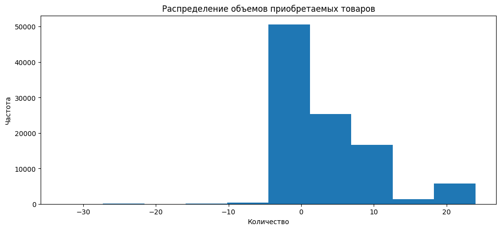

```python
# Устанавливаем размер графика
plt.figure(figsize=(12, 5))

# Строим гистограмму
plt.hist(retail_data['quantity'], bins=10)

# Добавляем названия осей X и Y
plt.xlabel('Количество')
plt.ylabel('Частота')

# Добавляем заголовок графика
plt.title('Распределение объемов приобретаемых товаров')

# Отображаем график
plt.show()
```

Нам удалось сгладить разброс. Редкие отрицательные значительные значения пока оставим, поскольку нам важно для расчетов использовать инфоормацию о приобретении.  
Нас всё ещё беспокоти значение 0 на шкале. Рассмотрим его подробней в различных срезах.

```python
retail_data.query('quantity == 0')['quantity'].count()
```

```
33055
```

33055 - ровно столько нулей в наборе. Это очень большое количество. Имеет место вероятная ошибка в данных. Углубимся в анализ и рассмотрим эта данные в разных срезах.

```python
#оставляем в наборе только данные с нулями
rdq = retail_data.copy()
rdq = rdq.query('quantity == 0')
rdq['year'] = retail_data['purchase_date'].dt.year
rdq['week'] = retail_data['purchase_date'].dt.isocalendar().week
rdq['date'] = retail_data['purchase_date'].dt.date
```

```python
#проверка различных срезов

#rdq.groupby('purchase_id').agg({'quantity':'count'}).sort_values('quantity', ascending=False).reset_index().head(50)
#rdq.groupby('item_id').agg({'quantity':'count'}).sort_values('quantity', ascending=False).reset_index().head(50)
#rdq.groupby('customer_id').agg({'quantity':'count'}).sort_values('quantity', ascending=False).reset_index().head(50)
#rdq.groupby(['year','week']).agg({'quantity':'count'}).sort_values('quantity', ascending=False).plot()
#rdq.groupby('shop_id').agg({'quantity':'count'}).sort_values('quantity', ascending=False).reset_index().head(50)
```

```python
#очищаем память
del rdq
```

#### Проверка purchase_date

Проведем анализ дат

```python
#выделим дату в отдельную переменную для удобства анализа
date = retail_data[['purchase_date','customer_id','quantity','purchase_id']].copy()
date['year'] = retail_data['purchase_date'].dt.year
date['week'] = retail_data['purchase_date'].dt.isocalendar().week
```

```python
date
```

|  | purchase_date | customer_id | quantity | purchase_id | year | week |
| --- | --- | --- | --- | --- | --- | --- |
| 0 | 2016-12-10 12:50:00 | 18427 | 11 | 538280 | 2016 | 49 |
| 1 | 2016-12-14 14:11:00 | 22389 | 0 | 538862 | 2016 | 50 |
| 2 | 2016-12-14 13:50:00 | 22182 | 7 | 538855 | 2016 | 50 |
| 3 | 2017-02-09 15:33:00 | 23522 | 0 | 543543 | 2017 | 6 |
| 4 | 2017-02-13 14:40:00 | 23151 | 0 | 543812 | 2017 | 7 |
| ... | ... | ... | ... | ... | ... | ... |
| 100241 | 2016-12-13 11:21:00 | <NA> | 1 | 538566 | 2016 | 50 |
| 100242 | 2017-01-05 15:56:00 | 21143 | 0 | 540247 | 2017 | 1 |
| 100243 | 2016-12-09 14:05:00 | 23657 | 1 | 538068 | 2016 | 49 |
| 100244 | 2016-12-10 11:33:00 | 18427 | 11 | 538207 | 2016 | 49 |
| 100245 | 2017-02-14 15:35:00 | 21294 | 9 | 543977 | 2017 | 7 |

100246 rows × 6 columns

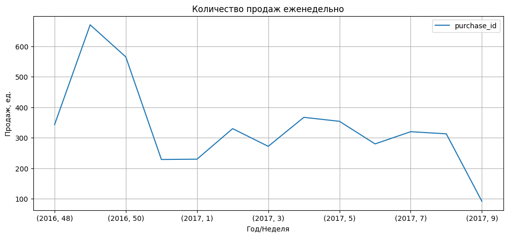

```python
# Группируем данные и строим график
ax = date.groupby(['year','week']).agg({'purchase_id':'nunique'}).plot(figsize=(12, 5), grid=True)

# Устанавливаем заголовок графика
ax.set_title('Количество продаж еженедельно')

# Устанавливаем подпись оси X
ax.set_xlabel('Год/Неделя')

# Устанавливаем подпись оси Y
ax.set_ylabel('Продаж, ед.')

# Отображаем график
plt.show()
```

#### Проверка customer_id

Мы уже выяснили, что на эту колонку приходится около трети пропусков. Восстановить такие пропуски не представляется возможным, т.к. признаков сегментирования клиента недостаточно. Заполним пропуски нулями и будем учитывать эти пропуски в дальнейшем.

```python
retail_data['customer_id'] = retail_data['customer_id'].fillna(0)
```

#### Проверка shop_id

```python
retail_data['shop_id'].unique()
```

```
array(['Shop 0', 'Shop 1', 'Shop 6', 'Shop 2', 'Shop 11', 'Shop 4',
       'Shop 3', 'Shop 7', 'Shop 12', 'Shop 8', 'Shop 27', 'Shop 5',
       'Shop 10', 'Shop 20', 'Shop 19', 'Shop 25', 'Shop 21', 'Shop 9',
       'Shop 18', 'Shop 28', 'Shop 16', 'Shop 29', 'Shop 17', 'Shop 22',
       'Shop 13', 'Shop 14', 'Shop 26', 'Shop 24', 'Shop 15', 'Shop 30'],
      dtype=object)
```

Некорректных значений не обнаружено

#### Проверка loyalty_program

```python
retail_data['loyalty_program'].unique()
```

```
<IntegerArray>
[0, 1]
Length: 2, dtype: Int64
```

С указанием участия в программе лояльности всё в порядке.

#### Проверка product_id

Типичные значения должны совпадать со списком unique_id. Попытаемся найти те, что отсутствуют в retail_data

```python
product_codes
```

|  | product_id | price_per_one |
| --- | --- | --- |
| 0 | 85123A | 2.55 |
| 1 | 71053 | 3.39 |
| 2 | 84406B | 2.75 |
| 3 | 84029G | 3.39 |
| 4 | 84029E | 3.39 |
| ... | ... | ... |
| 9964 | 84306 | 8.29 |
| 9965 | 90001A | 4.15 |
| 9966 | 90118 | 2.46 |
| 9967 | DOT | 172.62 |
| 9968 | 20738 | 0.00 |

9969 rows × 2 columns

```python
product_codes[~product_codes['product_id'].isin(unique_id['item_id'])]
```

|  | product_id | price_per_one |
| --- | --- | --- |
| 2958 | 21653 | 0.0 |
| 3659 | 84968B | 0.0 |
| 4653 | 21431 | 0.0 |
| 6402 | 21589 | 0.0 |
| 6410 | 72038P | 0.0 |
| 6435 | 84546 | 0.0 |
| 6699 | 17011A | 0.0 |
| 8743 | 84455 | 0.0 |
| 8744 | 84227 | 0.0 |
| 8761 | 84967A | 0.0 |
| 8762 | 84967B | 0.0 |
| 8763 | 84966B | 0.0 |
| 8764 | 84966A | 0.0 |
| 8774 | DCGS0055 | 0.0 |
| 8775 | DCGS0072 | 0.0 |
| 8776 | DCGS0074 | 0.0 |
| 8818 | 20864 | 0.0 |
| 8820 | 21282 | 0.0 |
| 8822 | 21805 | 0.0 |
| 8823 | 21841 | 0.0 |
| 8824 | 22143 | 0.0 |
| 8826 | 35644 | 0.0 |
| 8827 | 35991 | 0.0 |
| 8829 | 84424A | 0.0 |
| 8830 | 84509F | 0.0 |
| 8831 | 84526 | 0.0 |
| 8832 | 84664 | 0.0 |
| 8833 | 84964B | 0.0 |
| 8835 | 85028L | 0.0 |
| 8836 | 85028S | 0.0 |
| 8838 | 85110 | 0.0 |
| 8840 | 85179B | 0.0 |
| 8842 | 90000C | 0.0 |
| 8843 | 90095 | 0.0 |
| 8844 | 90091 | 0.0 |
| 8845 | DCGS0057 | 0.0 |
| 9148 | 84612B | 0.0 |
| 9168 | 35969 | 0.0 |
| 9968 | 20738 | 0.0 |

Небольшое количество отсутствует в датасете reta_data, это может быть следствием нашей очистки данных. В любом случае, их данные нам уже не понадобятся.

#### Проверка price_per_one

Проверим распределение цен.

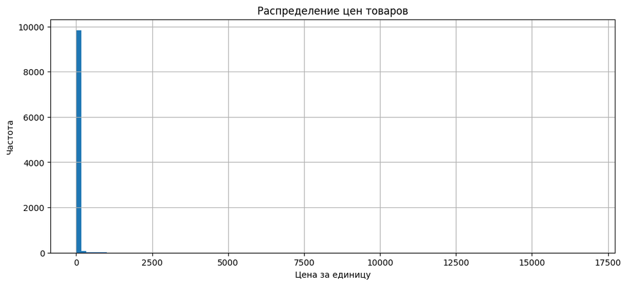

```python
# Строим гистограмму
ax = product_codes['price_per_one'].hist(bins=100, figsize=(12, 5))

# Устанавливаем заголовок графика
ax.set_title('Распределение цен товаров')

# Устанавливаем подпись оси X
ax.set_xlabel('Цена за единицу')

# Устанавливаем подпись оси Y
ax.set_ylabel('Частота')

# Отображаем график
plt.show()
```

Подавляющее болшинство стоит менее 1000 у.е. Мы наблюдаем сильный разброс от нуля и до нескольких тысяч за единицу товара. Узнаем, что это за товары.

```python
product_codes.groupby('product_id') \
.agg({'price_per_one':'mean'}) \
.reset_index() \
.sort_values('price_per_one', ascending=False) \
.head(15)
```

|  | product_id | price_per_one |
| --- | --- | --- |
| 3136 | AMAZONFEE | 9268.762222 |
| 3137 | BANK CHARGES | 385.947500 |
| 3150 | DOT | 278.734425 |
| 3151 | M | 253.765932 |
| 1507 | 22655 | 228.500000 |
| 1671 | 22826 | 175.000000 |
| 1673 | 22828 | 155.000000 |
| 1672 | 22827 | 155.000000 |
| 1508 | 22656 | 150.000000 |
| 1668 | 22823 | 117.500000 |
| 3139 | D | 77.072308 |
| 3138 | C2 | 71.666667 |
| 773 | 21769 | 66.360000 |
| 1770 | 22929 | 61.475000 |
| 2374 | 84632 | 59.950000 |

Как видно из таблицы, на первые места вышли операции не связанные с товарами. Такие значения можно не считать аномальными. Рассмотрим распределение внутри товарной группы, для этого разобьем product_id по категориям:

- product - товар
- other - другое

```python
#расставляем маркеры
product_codes['item_type'] = ''
product_codes.loc[product_codes['product_id'].isin(special_codes), 'item_type'] = 'other'
product_codes.loc[~product_codes['product_id'].isin(special_codes), 'item_type'] = 'product'
```

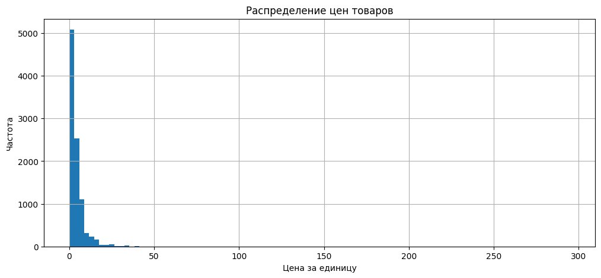

```python
# Фильтруем по типу "product" и строим гистограмму
ax = product_codes.query('item_type=="product"')['price_per_one'].hist(bins=100, figsize=(12, 5))

# Устанавливаем заголовок графика
ax.set_title('Распределение цен товаров')

# Устанавливаем подпись оси X
ax.set_xlabel('Цена за единицу')

# Устанавливаем подпись оси Y
ax.set_ylabel('Частота')

# Отображаем график
plt.show()
```

Мы всё ещё наблюдаем картинку редких значений. Однако на аномальности не похоже, поскольку товар вполне может столько стоить. Но поскольку разброс велик и большие значения могут сильно исказить подсчеты, исключим товары с высокой стоимостью из нашего набора данных.

```python
#подсчитаем 95% процентиль
expensive_products_percent = np.percentile(product_codes.query('item_type=="product"')['price_per_one'], 95)
#составим список артикулов дорогих товаров
expensive_products_list = product_codes.query('item_type=="product" and price_per_one > @expensive_products_percent') \
['product_id'].unique()
```

```python
expensive_products_percent
```

```
12.75
```

```python
#отсеиваем дорогие товары по списку
product_codes = product_codes.query('~product_id.isin(@expensive_products_list)')
```

### Поиск дублей

#### Поиск явных дублей

```python
retail_data[retail_data.duplicated()]['purchase_id'].count()
```

```
1030
```

Довольно много дублей. Посмотрим их структуру.

```python
product_codes[product_codes['price_per_one']>1000]
```

|  | product_id | price_per_one | item_type |
| --- | --- | --- | --- |
| 3931 | AMAZONFEE | 13541.33 | other |
| 4089 | AMAZONFEE | 13474.79 | other |
| 4094 | AMAZONFEE | 5519.25 | other |
| 4095 | AMAZONFEE | 6706.71 | other |
| 5043 | M | 1130.90 | other |
| 5777 | M | 1298.40 | other |
| 6133 | AMAZONFEE | 16888.02 | other |
| 6134 | AMAZONFEE | 16453.71 | other |
| 6243 | M | 1126.00 | other |
| 8167 | M | 1283.80 | other |
| 8168 | BANK CHARGES | 1050.15 | other |
| 8729 | M | 1715.85 | other |
| 9476 | M | 1435.79 | other |
| 9732 | AMAZONFEE | 5575.28 | other |
| 9733 | AMAZONFEE | 5258.77 | other |

```python
retail_data[retail_data.duplicated(keep=False)].sort_values('purchase_id').head(50)
```

|  | purchase_id | item_id | quantity | purchase_date | customer_id | shop_id | loyalty_program |
| --- | --- | --- | --- | --- | --- | --- | --- |
| 51446 | 536409 | 22111 | 0 | 2016-12-01 11:45:00 | 23587 | Shop 0 | 1 |
| 21123 | 536409 | 22111 | 0 | 2016-12-01 11:45:00 | 23587 | Shop 0 | 1 |
| 38618 | 536409 | 22900 | 0 | 2016-12-01 11:45:00 | 23587 | Shop 0 | 1 |
| 34016 | 536409 | 21866 | 0 | 2016-12-01 11:45:00 | 23587 | Shop 0 | 1 |
| 27134 | 536409 | 22900 | 0 | 2016-12-01 11:45:00 | 23587 | Shop 0 | 1 |
| 23049 | 536409 | 22866 | 0 | 2016-12-01 11:45:00 | 23587 | Shop 0 | 1 |
| 53372 | 536409 | 21866 | 0 | 2016-12-01 11:45:00 | 23587 | Shop 0 | 1 |
| 57298 | 536409 | 22866 | 0 | 2016-12-01 11:45:00 | 23587 | Shop 0 | 1 |
| 4773 | 536412 | 21448 | 0 | 2016-12-01 11:49:00 | 23599 | Shop 0 | 1 |
| 62684 | 536412 | 22902 | 6 | 2016-12-01 11:49:00 | 23599 | Shop 0 | 1 |
| 11599 | 536412 | 21448 | 1 | 2016-12-01 11:49:00 | 23599 | Shop 0 | 1 |
| 82714 | 536412 | 21448 | 0 | 2016-12-01 11:49:00 | 23599 | Shop 0 | 1 |
| 22757 | 536412 | 22902 | 6 | 2016-12-01 11:49:00 | 23599 | Shop 0 | 1 |
| 76242 | 536412 | 22749 | 0 | 2016-12-01 11:49:00 | 23599 | Shop 0 | 1 |
| 18640 | 536412 | 21706 | 0 | 2016-12-01 11:49:00 | 23599 | Shop 0 | 1 |
| 73669 | 536412 | 22141 | 0 | 2016-12-01 11:49:00 | 23599 | Shop 0 | 1 |
| 47592 | 536412 | 21708 | 0 | 2016-12-01 11:49:00 | 23599 | Shop 0 | 1 |
| 4590 | 536412 | 22569 | 1 | 2016-12-01 11:49:00 | 23599 | Shop 0 | 1 |
| 79753 | 536412 | 22900 | 1 | 2016-12-01 11:49:00 | 23599 | Shop 0 | 1 |
| 84228 | 536412 | 22327 | 0 | 2016-12-01 11:49:00 | 23599 | Shop 0 | 1 |
| 29026 | 536412 | 85184C | 0 | 2016-12-01 11:49:00 | 23599 | Shop 0 | 1 |
| 74612 | 536412 | 22900 | 1 | 2016-12-01 11:49:00 | 23599 | Shop 0 | 1 |
| 67428 | 536412 | 21448 | 1 | 2016-12-01 11:49:00 | 23599 | Shop 0 | 1 |
| 15985 | 536412 | 21706 | 0 | 2016-12-01 11:49:00 | 23599 | Shop 0 | 1 |
| 88735 | 536412 | 22327 | 0 | 2016-12-01 11:49:00 | 23599 | Shop 0 | 1 |
| 18003 | 536412 | 21708 | 0 | 2016-12-01 11:49:00 | 23599 | Shop 0 | 1 |
| 40122 | 536412 | 22141 | 0 | 2016-12-01 11:49:00 | 23599 | Shop 0 | 1 |
| 99889 | 536412 | 21448 | 1 | 2016-12-01 11:49:00 | 23599 | Shop 0 | 1 |
| 47941 | 536412 | 22569 | 1 | 2016-12-01 11:49:00 | 23599 | Shop 0 | 1 |
| 8868 | 536412 | 22749 | 0 | 2016-12-01 11:49:00 | 23599 | Shop 0 | 1 |
| 97913 | 536412 | 22273 | 0 | 2016-12-01 11:49:00 | 23599 | Shop 0 | 1 |
| 75987 | 536412 | 85184C | 0 | 2016-12-01 11:49:00 | 23599 | Shop 0 | 1 |
| 82073 | 536412 | 22273 | 0 | 2016-12-01 11:49:00 | 23599 | Shop 0 | 1 |
| 30235 | 536446 | 21651 | 5 | 2016-12-01 12:15:00 | 21662 | Shop 0 | 0 |
| 57233 | 536446 | 21651 | 5 | 2016-12-01 12:15:00 | 21662 | Shop 0 | 0 |
| 81362 | 536464 | 22945 | 5 | 2016-12-01 12:23:00 | 23647 | Shop 0 | 1 |
| 21811 | 536464 | 22866 | 0 | 2016-12-01 12:23:00 | 23647 | Shop 0 | 1 |
| 6995 | 536464 | 22945 | 5 | 2016-12-01 12:23:00 | 23647 | Shop 0 | 1 |
| 4632 | 536464 | 22866 | 0 | 2016-12-01 12:23:00 | 23647 | Shop 0 | 1 |
| 53362 | 536464 | 21992 | 0 | 2016-12-01 12:23:00 | 23647 | Shop 0 | 1 |
| 30543 | 536464 | 22866 | 0 | 2016-12-01 12:23:00 | 23647 | Shop 0 | 1 |
| 84827 | 536464 | 21992 | 0 | 2016-12-01 12:23:00 | 23647 | Shop 0 | 1 |
| 18495 | 536488 | 84347 | 0 | 2016-12-01 12:31:00 | 23576 | Shop 0 | 1 |
| 43534 | 536488 | 84347 | 0 | 2016-12-01 12:31:00 | 23576 | Shop 0 | 1 |
| 478 | 536522 | 21122 | 0 | 2016-12-01 12:49:00 | 20691 | Shop 0 | 0 |
| 67659 | 536522 | 21121 | 0 | 2016-12-01 12:49:00 | 20691 | Shop 0 | 0 |
| 72239 | 536522 | 21122 | 0 | 2016-12-01 12:49:00 | 20691 | Shop 0 | 0 |
| 38314 | 536522 | 21121 | 0 | 2016-12-01 12:49:00 | 20691 | Shop 0 | 0 |
| 91860 | 536528 | 22411 | 0 | 2016-12-01 13:17:00 | 21204 | Shop 0 | 0 |
| 28956 | 536528 | 22865 | 0 | 2016-12-01 13:17:00 | 21204 | Shop 0 | 0 |

Много повторяющихся операций. Зная возможности кассовой техники - одной операции должно соответствовать одно время, а товарные позиции в чеке не повторяются. Из чего делается вывод, что это явные дубли, которые мы можем удалить.

```python
#удаляем дубли
retail_data = retail_data.drop_duplicates()
```

#### Поиск неявных дублей

Источником неявных дублей в нашем случае могут быть строковые значения. Приведем написание к строчному и проверим, сколько дублей у нас станет.

```python
#проверяем на копии retail_data
retail_data_test = retail_data.copy()
#приводим к строчному виду
retail_data_test['purchase_id'] = retail_data_test['purchase_id'].str.lower()
retail_data_test['item_id'] = retail_data_test['item_id'].str.lower()
#выводим копии
retail_data_test[retail_data_test.duplicated()]
```

|  | purchase_id | item_id | quantity | purchase_date | customer_id | shop_id | loyalty_program |
| --- | --- | --- | --- | --- | --- | --- | --- |

Дублей не появилось. С неявными дублями разобрались.

```python
#освобождаем память
del retail_data_test
```

### Подведение итогов

Несмотря на большое количество строк в столбце (более 100 тысяч) не все данные оказались пригодными для анализа, как минимум в наборе данных:

- отрицательное количество в quantity и purchase_id начинающееся на 'C' - возвраты
- не все операции связаны с продажами товаров
- количество проданных товаров в трети случаев указано как 0
- часть периода данных приходится на праздники
- пропущена треть строк customer_id клиентов

Обнаруженные недочеты мы учтем при анализе данных в будущем.

## Исследовательский анализ

- подсчитать количество участников программы
- подсчитать среднее/медианное количество заказов на участников программы и остальных покупателей
- подсчитать ср. чек участников программы и остальных покупателей
- подсчитать среднее/медианное количество предметов в чеке на участников программы и остальных покупателей
- определить возможные расчетные метрики и выполнить подсчет

### Подсчет участников программы лояльности

Подсчитаем количество участников программы лояльности. Т.к. нулевые customer_id - это клиенты инкогнито для нас и определить их число не представляется возможным. Вместо этого сосредоточимся на тех, что уже нам известны.

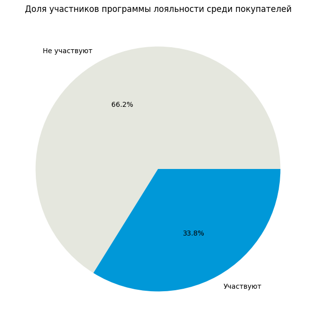

```python
#считаем участников программы
loyalty = retail_data.query('customer_id != 0').groupby('loyalty_program').agg({'customer_id':'nunique'})['customer_id']

#строим pie chart
fig, ax = plt.subplots(figsize=(8,8))
labels = ['Не участвуют', 'Участвуют']
colors = ['#e5e7de', '#0098d8']
ax.pie(loyalty, labels=labels, colors=colors, autopct='%1.1f%%')
ax.set_title('Доля участников программы лояльности среди покупателей')
plt.show();
```

Практически **33,8% наших покупателей принимают участие в программе лояльности**.

Ещё один важный вопрос: есть ли у нас клиенты которые делали покупки до того, как стали участниками? Это важно учесть в когортном анализе.

```python
retail_data.query('customer_id != 0').groupby('customer_id').agg({'loyalty_program':'nunique'}).query('loyalty_program > 1')
```

|  | loyalty_program |
| --- | --- |
| customer_id |  |

Как видим, **наши данные не учитывают "перебежчиков" из неучавствующих в лояльных и наоборот**.

Теперь попытаемся сосчитать средний чек для наших покупателей. Цены для наших товаров содержатся в файле product_codes. Интересная особенность в том, что для каждого товара мы имеет по несколько цен. Здесь может быть несколько предположений:

1. Это цены которые предоставляются по определенным условиям : по карте, без скидок, для юр. лиц и т.п.
2. Это может быть просто история цен по каждому товару.

Как проверить первую гипотезу - неясно: мы не знаем ни условия предоставления скидок, ни по каким ценам закупался клиент. Даже при верности это гипотезы, остается неизвестным - какую всё же клиент заплатил цену и как тут выбрать из 4, 5, 6 цен?

Во втором случае частичным подтверждением того, что это исторические цены может служить их количество - чем больше товар находился на полке, тем больше меняющихся ценников имел. Но нам неизвестна норма распределения таких товаров в ассортименте: каково соотношение старых товаров по отношению к новым? Отражает ли 3-х месячный период это распределение? Насколько изменчива стрктура? Мы это можем узнать, только анализируя исторические данные, которых не имеем.

Ответить на вопрос: какую цену стоит поставить товару - сложно. Возьмем для расчета верхню планку для каждой товарной позиций. Не смотря на то, что мы не занем точной суммы чека, мы можем отследить повышение количества позиций в чеке, или объема закупки товара, которые прямо влияют на среднюю сумму чека.  
Повышение этих показателей в группе будет говорить нам, что программа стимулирет клиентов приобретать больше.

Преждем чем приступить к расчетам, вспомним ограничения в данных:

- отрицательное количество в quantity и purchase_id начинающееся на 'C' - возвраты
- не все операции связаны с продажами товаров
- количество проданных товаров в трети случаев указано как 0
- пропущена треть строк customer_id клиентов
- удалены часть данных по товарам, такие чеки лучше не брать в расчет

Подготовим новый набор данных учетом этих ограничений.

```python
#определяем чеки с нулями в quantity, либо дорогие чеки
bad_checks = retail_data.query('quantity == 0 or item_id.isin(@expensive_products_list)')['purchase_id'].unique()

#clean_retail_data
#избавляемся от ограничений
crd = retail_data.query('customer_id != 0 and ~purchase_id.isin(@bad_checks)').reset_index(drop=True)
```

Теперь можем приступить к добавлению цен. Но сначала составим таблицу цен, которые нам нужны.

```python
#ставим максимальную цену для каждой позиции
price_list = (
    product_codes
    .groupby('product_id', as_index=False)
    .agg({'price_per_one':'max'})
    .rename(columns={'product_id':'item_id'})
)

#присоединяем таблицы
crd = crd.merge(price_list, how='left', on='item_id')

#считаем суммарную стоимость позиции
crd['price_per_pos'] = crd['quantity'] * crd['price_per_one']
```

```python
crd['purchase_id'].nunique()
```

```
1208
```

**Комментарий ревьюера**

**#ок**

Да, максимум - хороший выбор для цены

Мы не исключили из нашего набора данных операции не связанные с товарами. Список таких операций мы определили в special_codes.

```python
print(*crd[crd['item_id'].isin(special_codes)]['item_id'].unique(), sep=' -- ')
```

```
POST -- M -- C2 -- D
```

В наборе сохранились самые повторяющиеся особые операции. Не смотря на то, что это скорее всего не продажи товаров, это могут быть продажи услуг.

Рассмотрим распределение цен.

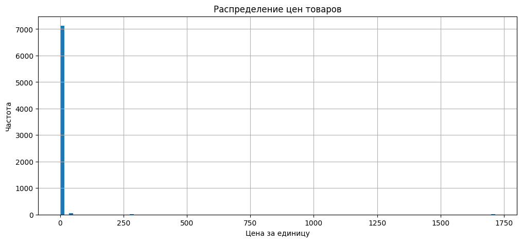

```python
# Фильтруем по типу "product" и строим гистограмму
ax = crd['price_per_one'].hist(bins=100, figsize=(12, 5))

# Устанавливаем заголовок графика
ax.set_title('Распределение цен товаров')

# Устанавливаем подпись оси X
ax.set_xlabel('Цена за единицу')

# Устанавливаем подпись оси Y
ax.set_ylabel('Частота')

# Отображаем график
plt.show()
```

На графике мы определенно имеем сильно отклоняющиеся, от обычных, цены.  
Поскольку мы упрощали подход и ставили максимальные значения цен, то сюда может закрасться значительная ошибка. Особенность услуг в том, что цена может быть не фиксированной, а динамичной: например это может быть доставка, где стоимость напрямую зависит от объемов и длины пути.

```python
product_codes.query('product_id.isin(["POST", "M", "D"])').groupby('product_id').agg({'price_per_one':['min','max']})
```

| product_id | price_per_one min | price_per_one max |
| --- | --- | --- |
| D | 5.76 | 281.00 |
| M | 0.19 | 1715.85 |
| POST | 0.00 | 40.00 |

Все три значений серьезно разняться в минимальных и максимальных суммах. От таких значений стоит избавиться, чтобы не искажать общую картину. Поскольку это скорее всего не товар, то мы можем просто избавиться от этих позиций в чеке, а не исключать клиентов.

```python
crd = crd.query('~item_id.isin(@special_codes)')
```

В наборе данных остались возвраты. Т.к. предполагаемые возвраты оформляется отдельное операцией, которая не указывает, по какому чек осуществляет возврат, то вычесть точечно мы такое не можем. Помимо этого, возвраты не зависят от лояльности клиента: это может быть брак или сломавшийся ранее времени инструмент.

```python
crd = crd.query('quantity > 0')
```

Проверим, как изменился состав участников нашего набора данных

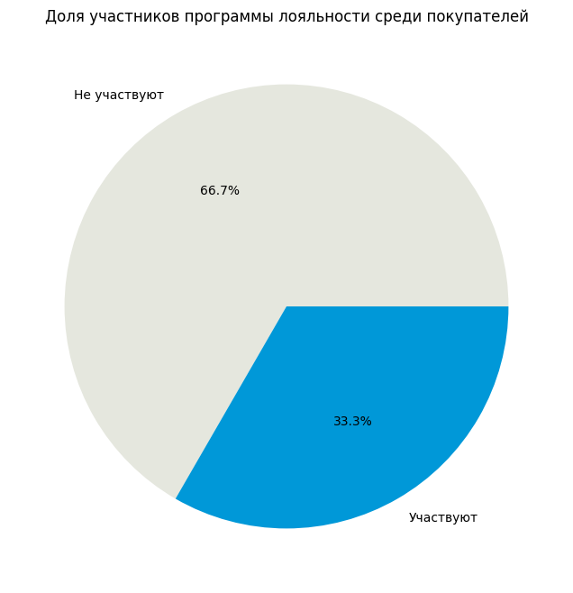

```python
loyalty = crd.groupby('loyalty_program').agg({'customer_id':'nunique'})['customer_id']

fig, ax = plt.subplots(figsize=(8,8))
labels = ['Не участвуют', 'Участвуют']
colors = ['#e5e7de', '#0098d8']
ax.pie(loyalty, labels=labels, colors=colors, autopct='%1.1f%%')
ax.set_title('Доля участников программы лояльности среди покупателей')
plt.show();
```

Теперь, когда мы отсеяли лишнее, можем приступить к подсчетам среднего чека для каждой группы клиентов.

### Средний чек клиента

Рассмотрим общую картину распределения средней выручки по каждому клиенту.

```python
customer_mean_check = (
    crd.groupby(['loyalty_program','customer_id'], as_index=False)
    .agg({'price_per_pos':'sum','purchase_id':'nunique'})
    .rename(columns={'price_per_pos':'total_revenue', 'purchase_id':'num_of_cheks'})
)

customer_mean_check['avg_check'] = customer_mean_check['total_revenue'] / customer_mean_check['num_of_cheks']
```

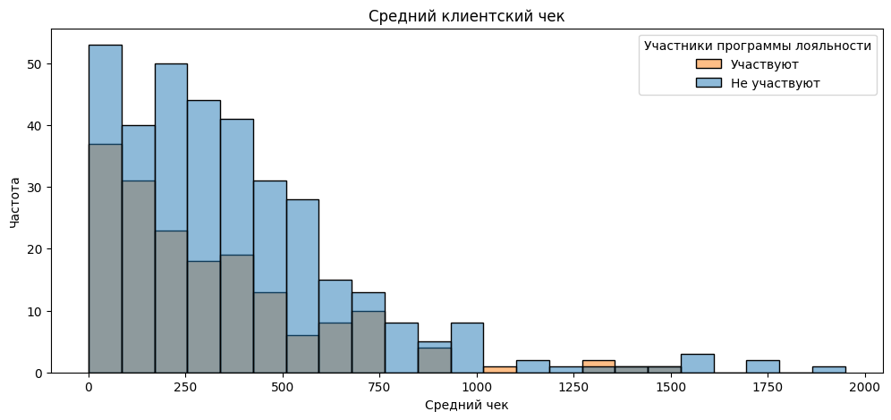

```python
# Рисуем гистограмму
fig = plt.figure(figsize=(12, 5))
ax = sns.histplot(x='avg_check', hue='loyalty_program', data=customer_mean_check)

# Устанавливаем заголовок графика
ax.set_title('Средний клиентский чек')

# Устанавливаем подпись оси X
ax.set_xlabel('Средний чек')

# Устанавливаем подпись оси Y
ax.set_ylabel('Частота')

# Добавляем легенду
ax.legend(title='Участники программы лояльности', labels=['Участвуют', 'Не участвуют'])

# Отображаем график
plt.show()
```

Размеры в среднем потраченных сумм среди клиентов довольно однородны, но всё же хвост остался длинным. Отсеем редких клиентов.

```python
#Определим 95% процентиль
avg_check_perc = np.percentile(customer_mean_check['avg_check'], 95)

# Определяем нетипичного клиента
bad_customer = customer_mean_check.query('avg_check > @avg_check_perc')['customer_id'].unique()

# Убираем его операции из набора данных
crd = crd.query('~customer_id.isin(@bad_customer)')

#Убираем его операции из переменной
customer_mean_check = customer_mean_check.query('avg_check < @avg_check_perc')
```

Посмотрим на распределение сумм чеков

```python
# Аггрегируем данные сумм по каждому чеку с разбивкой по программам лояльности
check_sum = (
    crd.groupby(['loyalty_program','purchase_id'], as_index=False)
    .agg({'price_per_pos':'sum'})
    .rename(columns={'price_per_pos':'total_sum'})
)
```

[figure not shown]

```python
# Рисуем гистограмму
fig = plt.figure(figsize=(12, 5))
ax = sns.histplot(x='total_sum', hue='loyalty_program', data=check_sum)

# Устанавливаем заголовок графика
ax.set_title('Суммы чеков')

# Устанавливаем подпись оси X
ax.set_xlabel('ID чека')

# Устанавливаем подпись оси Y
ax.set_ylabel('Сумма чека')

# Добавляем легенду
ax.legend(title='Участники программы лояльности', labels=['Участвуют', 'Не участвуют'])

# Отображаем график
plt.show()
```

Хвост очень длинный. Избавимся от больших значений.

```python
#Определяем 95% процентиль
total_sum_perc = np.percentile(check_sum['total_sum'], 95)

# Определяем аномально больше чеки
bad_check = check_sum.query('total_sum > @total_sum_perc')['purchase_id'].unique()

# Убираем их операции из набора данных
crd = crd.query('~purchase_id.isin(@bad_check)')
```

Подсчитаем общие средние размеров чеков обеих групп.

```python
group_mean_check = customer_mean_check.groupby('loyalty_program', as_index=False).agg({'avg_check':'mean'})
group_mean_check['avg_check'] = round(group_mean_check['avg_check'],2)

print('Средний чек участников программы：{} ，средний чек остальных покупателей:{}'.format(group_mean_check['avg_check'][1],group_mean_check['avg_check'][0]))
```

```
Средний чек участников программы：283.26 ，средний чек остальных покупателей:319.43
```

Подсчитаем ср. ежедневную выручку наших групп клиентов. Для удобства добавим столбцы с годом/неделей/днем.

```python
# Разбиваем для удобства обработки дату
crd['year'] = crd['purchase_date'].dt.year
crd['week'] = crd['purchase_date'].dt.isocalendar().week
crd['date'] = crd['purchase_date'].dt.date
```

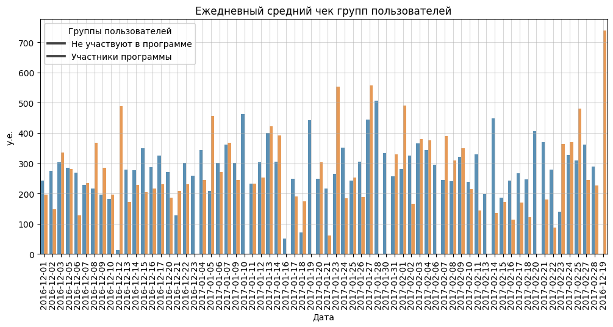

```python
# Агреггируем суммы чека и количество на каждого клиента в разбивке по участию в программе и дням
daily_avg_check = (
    crd.groupby(['loyalty_program','date'], as_index=False)
    .agg({'price_per_pos':'sum','purchase_id':'nunique'})
    .rename(columns={'price_per_pos':'total_revenue', 'purchase_id':'num_of_cheks'})
)

# Вычисляем средний чек за день
daily_avg_check['daily_avg_check'] = daily_avg_check['total_revenue'] / daily_avg_check['num_of_cheks']

# # Задаем размеры графика
# plt.figure(figsize=(12, 5))

# # Строим графики
# ax = sns.lineplot(data=daily_avg_check, x='date', y='daily_avg_check', hue='loyalty_program')
# ax.set(xlabel='Дата', ylabel='У.е.', title='Ежедневный средний чек групп пользователей')
# plt.xticks(rotation=45)

# # Указываем попдиси
# new_labels = ['Не участвуют в программе', 'Участники программы']
# for t, l in zip(ax.legend().texts, new_labels):
#     t.set_text(l)

# # Добавляем сетку на график
# ax.grid(which='major', axis='both', alpha=0.5)

# plt.show();
daily_avg_check
# Задаем размеры графика
plt.figure(figsize=(12, 5))

# Строим график
sns.barplot(data=daily_avg_check, x='date', y='daily_avg_check', hue='loyalty_program', alpha=0.8)

# Устанавливаем подписи осей и заголовок
plt.xlabel('Дата')
plt.ylabel('у.е.')
plt.title('Ежедневный средний чек групп пользователей')

# Поворачиваем надписи на оси x на 45 градусов
plt.xticks(rotation=90)

# Указываем легенду и ее названия
new_labels = ['Не участвуют в программе', 'Участники программы']
plt.legend(title='Группы пользователей', labels=new_labels)
#
# Добавляем сетку на график
plt.grid(which='major', axis='both', alpha=0.5)

plt.show()
```

На участке дат от 15 декабря до 15 января видно странное поведение графика, а именно его равномерность.

```python
retail_data['year'] = retail_data['purchase_date'].dt.year
retail_data['week'] = retail_data['purchase_date'].dt.isocalendar().week
retail_data['date'] = retail_data['purchase_date'].dt.date

gap = retail_data.groupby(['loyalty_program','date'], as_index=False).agg({'purchase_id':'count'})
gap['date'] = pd.to_datetime(gap['date'])
gap[(gap['date'] >= '2016-12-23')&(gap['date'] <= '2017-01-04')]
```

|  | loyalty_program | date | purchase_id |
| --- | --- | --- | --- |
| 19 | 0 | 2016-12-23 | 839 |
| 20 | 0 | 2017-01-04 | 927 |
| 87 | 1 | 2016-12-23 | 93 |
| 88 | 1 | 2017-01-04 | 194 |

Мы нашли пробелы в данных: у нас **отсутствуют данные за период с 23 декабря по 04 января**. К тому же данные выглядят шумно, подсчитаем ср. чек для недель.

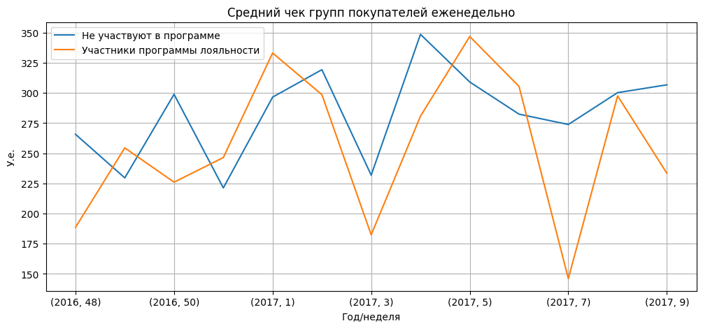

```python
# Аггрегируем данные понедельно
weekly_avg_check = crd.groupby(['loyalty_program', 'year','week'], as_index=False).agg({'price_per_pos':'sum','purchase_id':'nunique'})

weekly_avg_check['avg_weekly_check'] = weekly_avg_check['price_per_pos'] / weekly_avg_check['purchase_id']

# Группируем данные по году и номеру недели и считаем среднее значение числа участников и неучастников
weekly_avg_check = weekly_avg_check.pivot_table(values='avg_weekly_check', index=['year','week'], columns='loyalty_program', aggfunc='mean')
#729 an 692 1 week of 2017
weekly_avg_check
# Cтроимм график
fig, ax = plt.subplots(figsize=(12, 5)) # добавляем размер графика
weekly_avg_check.plot(grid=True, ax=ax)

# Устанавливаем подписи для осей и заголовок
ax.set_xlabel('Год/неделя')
ax.set_ylabel('У.е.')
ax.set_title('Cредний чек групп покупателей еженедельно')

# Устанавливаем легенду
ax.legend(labels=['Не участвуют в программе', 'Участники программы лояльности'])

plt.show()
```

Как можно увидеть из графика - размер среднего чека в группе участников программы лояльности даже ниже, чем у тех, кто не участвует в программе. Но это может быть следствием наших манипуляций ценами. Вероятно другие показатели укажут на повышение спроса среди участников программы?

### Среднее количество заказов

```python
group_avg_orders = (
    crd.groupby(['loyalty_program'], as_index=False)
    .agg({'purchase_id':'nunique', 'customer_id':'nunique'})
    .rename(columns={'purchase_id':'num_of_orders', 'customer_id':'num_of_clients'})
)
group_avg_orders

group_avg_orders['avg_orders'] = round(group_avg_orders['num_of_orders'] / group_avg_orders['num_of_clients'], 2)

print('Среднее количество заказов участников программы：{}  остальных покупателей:{}'.format(group_avg_orders['avg_orders'][1],group_avg_orders['avg_orders'][0]))
```

```
Среднее количество заказов участников программы：1.45  остальных покупателей:1.4
```

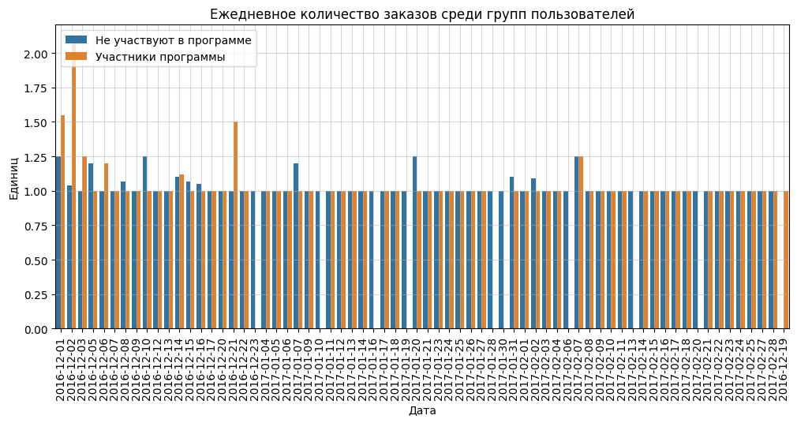

```python
# Агреггируем ср. количество заказов в разбивке по участию в программе и дням
daily_avg_orders = (
    crd.groupby(['loyalty_program','date'], as_index=False)
    .agg({'purchase_id':'nunique', 'customer_id':'nunique'})
    .rename(columns={'purchase_id':'num_of_orders', 'customer_id':'num_of_clients'})
)

daily_avg_orders['daily_avg_orders'] = round(daily_avg_orders['num_of_orders'] / daily_avg_orders['num_of_clients'], 2)

# # Задаем размеры графика
# plt.figure(figsize=(12, 5))

# # Строим графики
# ax = sns.lineplot(data=daily_avg_orders, x='date', y='daily_avg_orders', hue='loyalty_program')
# ax.set(xlabel='Дата', ylabel='Единиц', title='Ежедневное количество заказов среди групп пользователей')
# plt.xticks(rotation=45)

# # Указываем попдиси
# new_labels = ['Не участвуют в программе', 'Участники программы']
# for t, l in zip(ax.legend().texts, new_labels):
#     t.set_text(l)

# # Добавляем сетку на график
# ax.grid(which='major', axis='both', alpha=0.5)

# plt.show();

# Cтроим график
fig, ax = plt.subplots(figsize=(12, 5))

sns.barplot(data=daily_avg_orders, x='date', y='daily_avg_orders', hue='loyalty_program', ax=ax)
ax.set(xlabel='Дата', ylabel='Единиц', title='Ежедневное количество заказов среди групп пользователей')
plt.xticks(rotation=90)

# Указываем подписи
new_labels = ['Не участвуют в программе', 'Участники программы']
for t, l in zip(ax.legend().texts, new_labels):
    t.set_text(l)

# Добавляем сетку на график
ax.grid(which='major', axis='both', alpha=0.5)

plt.show()
```

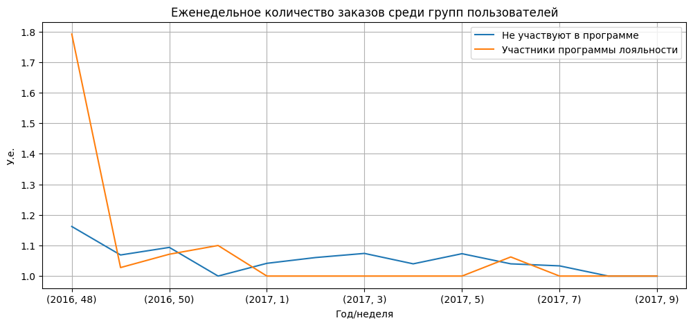

```python
# Аггрегируем данные понедельно
weekly_avg_orders = (crd.groupby(['loyalty_program', 'year','week'], as_index=False)
                     .agg({'purchase_id':'nunique', 'customer_id':'nunique'})
                     .rename(columns={'purchase_id':'num_of_orders', 'customer_id':'num_of_clients'})
                    )

weekly_avg_orders['avg_avg_orders'] = weekly_avg_orders['num_of_orders'] / weekly_avg_orders['num_of_clients']

# Группируем данные по году и номеру недели и считаем среднее значение числа участников и неучастников
weekly_avg_orders = weekly_avg_orders.pivot_table(values='avg_avg_orders', index=['year','week'], columns='loyalty_program', aggfunc='mean')
#729 an 692 1 week of 2017
weekly_avg_orders
# Cтроимм график
fig, ax = plt.subplots(figsize=(12, 5)) # добавляем размер графика
weekly_avg_orders.plot(grid=True, ax=ax)

# Устанавливаем подписи для осей и заголовок
ax.set_xlabel('Год/неделя')
ax.set_ylabel('У.е.')
ax.set_title('Еженедельное количество заказов среди групп пользователей')

# Устанавливаем легенду
ax.legend(labels=['Не участвуют в программе', 'Участники программы лояльности'])

plt.show()
```

В целом графики получились малоинформативными, по ним можно разве что понять, что клиенты редко покупают что то в нашем магазине чаще чем раз в неделю.

В целом, частота заказов не сильно разнится среди групп, но в группе участников программы она слегка выше.

### Среднее количество товаров в чеке

```python
group_avg_position_a = (
    crd.groupby(['loyalty_program'], as_index=False)
    .agg({'quantity':'count', 'purchase_id':'nunique'})
    .rename(columns={'quantity':'num_of_pos', 'purchase_id':'num_of_checks'})
)

group_avg_position_a['avg_pos'] = round(group_avg_position_a['num_of_pos'] / group_avg_position_a['num_of_checks'], 2)


print('Среднее количество позиций чека участников программы：{}, остальных покупателей:{}'.format(group_avg_position_a['avg_pos'][1],group_avg_position_a['avg_pos'][0]))
```

```
Среднее количество позиций чека участников программы：6.27, остальных покупателей:7.08
```

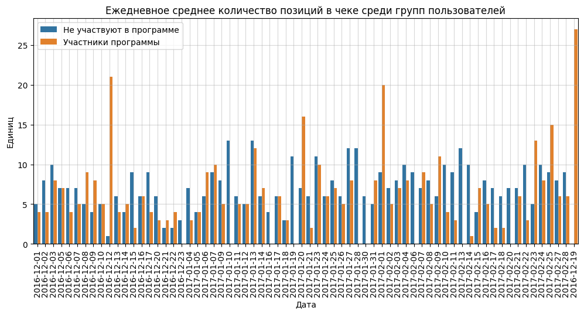

```python
# Агреггируем ср. количество заказов в разбивке по участию в программе и дням
group_avg_position = (
    crd.groupby(['loyalty_program','date'], as_index=False)
    .agg({'quantity':'count', 'purchase_id':'nunique'})
    .rename(columns={'quantity':'num_of_pos', 'purchase_id':'num_of_checks'})
)

group_avg_position['avg_pos'] = round(group_avg_position['num_of_pos'] / group_avg_position['num_of_checks'], 0)

# # Задаем размеры графика
# plt.figure(figsize=(12, 5))

# # Строим графики
# ax = sns.lineplot(data=group_avg_position, x='date', y='avg_pos', hue='loyalty_program')
# ax.set(xlabel='Дата', ylabel='Единиц', title='Ежедневное среднее количество позиций в чеке среди групп пользователей')
# plt.xticks(rotation=45)

# # Указываем попдиси
# new_labels = ['Не участвуют в программе', 'Участники программы']
# for t, l in zip(ax.legend().texts, new_labels):
#     t.set_text(l)

# # Добавляем сетку на график
# ax.grid(which='major', axis='both', alpha=0.5)

# plt.show();

# Задаем размеры графика
plt.figure(figsize=(12, 5))

# Строим графики
ax = sns.barplot(data=group_avg_position, x='date', y='avg_pos', hue='loyalty_program')
ax.set(xlabel='Дата', ylabel='Единиц', title='Ежедневное среднее количество позиций в чеке среди групп пользователей')
plt.xticks(rotation=90)

# Указываем попдиси
new_labels = ['Не участвуют в программе', 'Участники программы']
for t, l in zip(ax.legend().texts, new_labels):
    t.set_text(l)

# Добавляем сетку на график
ax.grid(which='major', axis='both', alpha=0.5)

plt.show();
```

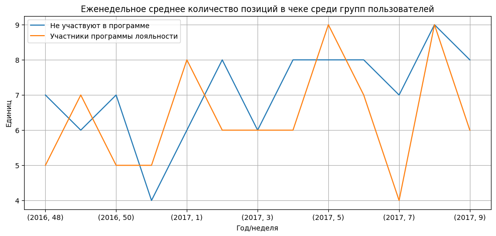

```python
# Аггрегируем данные понедельно
group_avg_position = (crd.groupby(['loyalty_program', 'year','week'], as_index=False)
                     .agg({'quantity':'count', 'purchase_id':'nunique'})
                     .rename(columns={'quantity':'num_of_pos', 'purchase_id':'num_of_checks'})
                    )

group_avg_position['avg_pos'] = round(group_avg_position['num_of_pos'] / group_avg_position['num_of_checks'], 0)

# Группируем данные по году и номеру недели и считаем среднее значение числа участников и неучастников
group_avg_position = group_avg_position.pivot_table(values='avg_pos', index=['year','week'], columns='loyalty_program', aggfunc='mean')

weekly_avg_orders
# Cтроимм график
fig, ax = plt.subplots(figsize=(12, 5)) # добавляем размер графика
group_avg_position.plot(grid=True, ax=ax)

# Устанавливаем подписи для осей и заголовок
ax.set_xlabel('Год/неделя')
ax.set_ylabel('Единиц')
ax.set_title('Еженедельное среднее количество позиций в чеке среди групп пользователей')

# Устанавливаем легенду
ax.legend(labels=['Не участвуют в программе', 'Участники программы лояльности'])

plt.show()
```

И по этому параметру участники группы лояльности отстают в среднем на 1 заказ.

### Средний доход с единицы товара в чеке

Посчитаем средний доход с единицы товара в чеке

```python
avg_price_per_pos_a = (
    crd.groupby(['loyalty_program'], as_index=False)
    .agg({'price_per_pos':'sum', 'quantity':'sum'})
    .rename(columns=({'price_per_pos':'check_sum'}))
 )

avg_price_per_pos_a['avg_pos'] = round(avg_price_per_pos_a['check_sum'] / avg_price_per_pos_a['quantity'], 2)

print('Средняя стоимость 1 единицы товара у участников программы：{} у.е., остальных покупателей:{}'.format(avg_price_per_pos_a['avg_pos'][1],avg_price_per_pos_a['avg_pos'][0]))
```

```
Средняя стоимость 1 единицы товара у участников программы：3.94 у.е., остальных покупателей:3.78
```

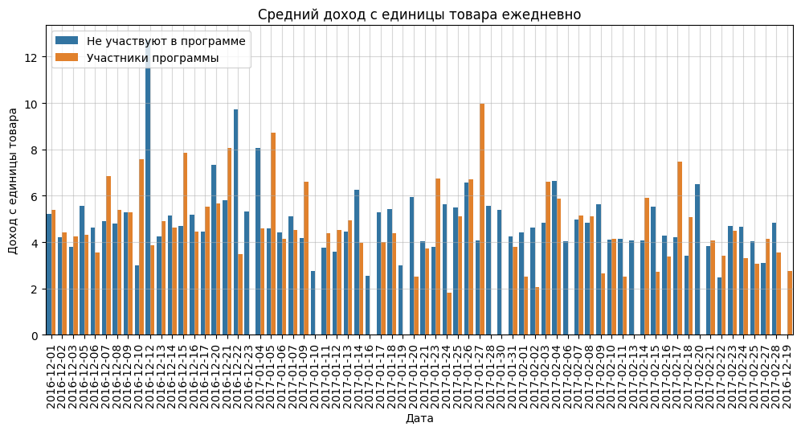

```python
avg_price_per_pos = (
    crd.groupby(['loyalty_program', 'date', 'purchase_id'], as_index=False)
    .agg({'price_per_pos':'sum', 'quantity':'sum'})
    .rename(columns=({'price_per_pos':'check_sum'}))
)

avg_price_per_pos['avg_price_per_pos'] = avg_price_per_pos['check_sum'] / avg_price_per_pos['quantity']

avg_price_per_pos = (avg_price_per_pos.groupby(['loyalty_program', 'date'], as_index=False)
                     .agg({'avg_price_per_pos':'mean'})
                    )

# # Задаем размеры графика
# plt.figure(figsize=(12, 5))

# #строим графики
# ax = sns.lineplot(data=avg_price_per_pos, x='date', y='avg_price_per_pos', hue='loyalty_program')
# ax.set(xlabel='Дата', ylabel='Доход с единицы товара', title='Средний доход с единицы товара ежедневно')
# plt.xticks(rotation=45)

# #указываем попдиси
# new_labels = ['Не участвуют в программе', 'Участники программы']
# for t, l in zip(ax.legend().texts, new_labels):
#     t.set_text(l)

# # Добавляем сетку на график
# ax.grid(which='major', axis='both', alpha=0.5)

# plt.show();

# Задаем размеры графика
plt.figure(figsize=(12, 5))

# Строим график
ax = sns.barplot(data=avg_price_per_pos, x='date', y='avg_price_per_pos', hue='loyalty_program')
ax.set(xlabel='Дата', ylabel='Доход с единицы товара', title='Средний доход с единицы товара ежедневно')
plt.xticks(rotation=90)

# Указываем попдиси
new_labels = ['Не участвуют в программе', 'Участники программы']
for t, l in zip(ax.legend().texts, new_labels):
    t.set_text(l)

# Добавляем сетку на график
ax.grid(which='major', axis='both', alpha=0.5)

plt.show();
```

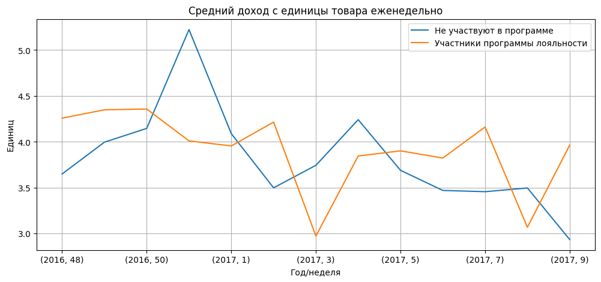

```python
# Аггрегируем данные понедельно
avg_price_per_pos = (crd.groupby(['loyalty_program', 'year','week'], as_index=False)
                     .agg({'price_per_pos':'sum', 'quantity':'sum'})
                     .rename(columns=({'price_per_pos':'check_sum'}))
                    )

avg_price_per_pos['avg_price_per_pos'] = avg_price_per_pos['check_sum'] / avg_price_per_pos['quantity']

avg_price_per_pos = (avg_price_per_pos.groupby(['loyalty_program', 'year','week'], as_index=False)
                     .agg({'avg_price_per_pos':'mean'})
                    )

# Группируем данные по году и номеру недели и считаем среднее значение числа участников и неучастников
avg_price_per_pos = avg_price_per_pos.pivot_table(values='avg_price_per_pos', index=['year','week'], columns='loyalty_program', aggfunc='mean')

# Cтроимм график
fig, ax = plt.subplots(figsize=(12, 5)) # добавляем размер графика
avg_price_per_pos.plot(grid=True, ax=ax)

# Устанавливаем подписи для осей и заголовок
ax.set_xlabel('Год/неделя')
ax.set_ylabel('Единиц')
ax.set_title('Средний доход с единицы товара еженедельно')

# Устанавливаем легенду
ax.legend(labels=['Не участвуют в программе', 'Участники программы лояльности'])

plt.show()
```

### Расчет LTV

Подсчитаем показатели LTV для обеих групп

Составим функцию.

```python
def get_ltv(
    df,  # Шаг 1. Получить профили и данные о покупках
    observation_date,
    horizon_days, #передаем недели, а не дни, т.к. у нас есть пропуски в днях
    dimensions=[],
    ignore_horizon=False,
):

    # исключаем пользователей, не «доживших» до горизонта анализа
    last_suitable_acquisition_date = observation_date
    if not ignore_horizon:
        last_suitable_acquisition_date = observation_date - timedelta(
            days=horizon_days - 1
        )
    result_raw = df.query('first_purchase <= @last_suitable_acquisition_date').copy()

    # Шаг 2. Рассчитать лайфтайм пользователя для каждой покупки
    result_raw['lifetime'] = (
        result_raw['last_purchase'] - result_raw['first_purchase']
    ).dt.days

    # группируем по cohort, если в dimensions ничего нет
    if len(dimensions) == 0:
        result_raw['cohort'] = 'All users'
        dimensions = dimensions + ['cohort']

    # Шаг 2.1 #функция заполнения lifetime пробелов
    def fill_lt(result_raw):
        #список пропущенных lifetime
        diff = set(list(range(result_raw['lifetime'].max()))) - set(result_raw['lifetime'].unique().tolist())
        diff = list(diff)

        #добавляем пропуски в data frame
        if diff != []:
            # создаем новую строку
            for i in range(len(diff)):
                new_row = {'lifetime': diff[i]}
                result_raw = result_raw.append(new_row, ignore_index=True)
            result_raw['lifetime'] = result_raw['lifetime'].astype('int')
            return result_raw
        else:
            return result_raw

    #функция дополнения lifetime пробелом
    result_raw = fill_lt(result_raw)
    result_raw['loyalty_program'] = result_raw['loyalty_program'].fillna(0)
    # функция для группировки таблицы по желаемым признакам
    def group_by_dimensions(df, dims, horizon_days):

        # Шаг 4. Построить таблицу выручки
        # строим «треугольную» таблицу
        result = df.pivot_table(
            index=dims,
            columns='lifetime',
            values='revenue',  # в ячейках — выручка за каждый лайфтайм
            aggfunc='sum',
        )

        # Шаг 5. Посчитать сумму выручки с накоплением
        result = result.fillna(0).cumsum(axis=1)

        # Шаг 6. Вычислить размеры когорт
        cohort_sizes = (
            df.groupby(dims)
            .agg({'user_id': 'nunique'})
            .rename(columns={'user_id': 'cohort_size'})
        )

        # Шаг 7. Объединить размеры когорт и таблицу выручки
        result = cohort_sizes.merge(result, on=dims, how='left').fillna(0)

        # Шаг 8. Посчитать LTV
        # делим каждую «ячейку» в строке на размер когорты
        result = result.div(result['cohort_size'], axis=0)
        # исключаем все лайфтаймы, превышающие горизонт анализа
        result = result[['cohort_size'] + list(range(horizon_days))]
        # восстанавливаем размеры когорт
        result['cohort_size'] = cohort_sizes
        return result

    # получаем таблицу LTV
    result_grouped = group_by_dimensions(result_raw, dimensions, horizon_days)

    # для таблицы динамики LTV убираем 'cohort' из dimensions
    if 'cohort' in dimensions:
        dimensions = []
    # получаем таблицу динамики LTV
#     result_in_time = group_by_dimensions(
#         result_raw, dimensions + ['dt'], horizon_days
#     )

    # возвращаем обе таблицы LTV и сырые данные
    return result_raw, result_grouped#, result_in_time
```

Подготовим агрегированные данные

```python
#агрегируем данные
crd['month'] = crd['purchase_date'].dt.month_name()
ltv_data = crd.groupby('customer_id', as_index=False).agg({'purchase_date':['min','max'], 'price_per_pos':'sum', 'loyalty_program':'max', 'month':'nunique'}).copy()
ltv_data.columns = ['user_id','first_purchase','last_purchase', 'revenue', 'loyalty_program','lp_count']
ltv_data['dt'] = ltv_data['first_purchase'].dt.date
ltv_data.loc[ltv_data['loyalty_program']==0, 'lp_count'] = 0

#добавляем 200 рублей
ltv_data.loc[ltv_data['loyalty_program']==1, 'revenue'] = (
    ltv_data.loc[ltv_data['loyalty_program']==1, 'revenue'] +
    (ltv_data.loc[ltv_data['loyalty_program']==1, 'lp_count'] * 200)
)
```

Построим кривые LTV

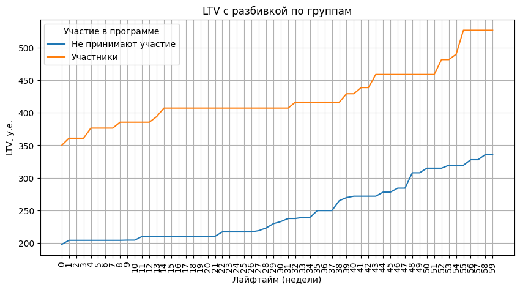

```python
ltv_raw, ltv = get_ltv(ltv_data, datetime(2017, 3, 1).date(), 60, dimensions=['loyalty_program'])

report = ltv.drop(columns=['cohort_size'])
report.T.plot(grid=True, figsize=(10, 5), xticks=list(report.columns.values))
plt.title('LTV с разбивкой по группам')
plt.ylabel('LTV, у.е.')
plt.xlabel('Лайфтайм (недели)')
plt.legend(title='Участие в программе', labels=['Не принимают участие','Участники'])
plt.xticks(rotation=90)
plt.show()
```

Как видно из графика, показатель LTV в группе выше чем у остальных.

### Общий вывод

Устойчивых показателей преимущества в доходе среди участников программы лояльности над остальными покупателями мы не обнаружили.

```python
print('Портрет участников программы лояльности складывается такой:')
print('Средний чек участников программы：{} ，средний чек остальных покупателей:{}'.format(group_mean_check['avg_check'][1],group_mean_check['avg_check'][0]))
print()
print('Другие косвенные показатели среди групп, которые себя не проявили и были приблизительно похожи, речь об:')
print('Среднее количество заказов участников программы {},  остальных покупателей:{}'.format(group_avg_orders['avg_orders'][1],group_avg_orders['avg_orders'][0]))
print('Среднее количество позиций чека участников программы {}, остальных покупателей:{}'.format(group_avg_position_a['avg_pos'][1],group_avg_position_a['avg_pos'][0]))
print('Средняя стоимость 1 единицы товара у участников программы {} у.е., остальных покупателей:{}'.format(avg_price_per_pos_a['avg_pos'][1],avg_price_per_pos_a['avg_pos'][0]))
print('LTV клиентов учавствующих в программе за весь срок жизни опережает остальных покупателей')
```

```
Портрет участников программы лояльности складывается такой:
Средний чек участников программы：283.26 ，средний чек остальных покупателей:319.43

Другие косвенные показатели среди групп, которые себя не проявили и были приблизительно похожи, речь об:
Среднее количество заказов участников программы 1.45,  остальных покупателей:1.4
Среднее количество позиций чека участников программы 6.27, остальных покупателей:7.08
Средняя стоимость 1 единицы товара у участников программы 3.94 у.е., остальных покупателей:3.78
LTV клиентов учавствующих в программе за весь срок жизни опережает остальных покупателей
```

Из данных цифр мы видим основную разницу в среднем чеке и ср. количестве позиций в чеке. Попытаемся установить, случайным ли образом возникла разница или это устойчивый результат.

## Тестирование статистических гипотез

Нам необходимо проверить 2 гипотезы:

1. Между группами клиентов существует разница в среднем чеке.
2. Между группами клиентов существует разница в количестве позиций в чеке.

### Проверка гипотезы о разнице среднего чека

Набор данных для анализа: customer_mean_check

Наши гипотезы звучат следующим образом:  
**H0**: Разницы в средних чеках между группами нет  
**H1**: Средний чек покупателей не входящих в группу участников программы лояльности больше чем у клиентов, входящих в нее

Рассмотрим распределение значений

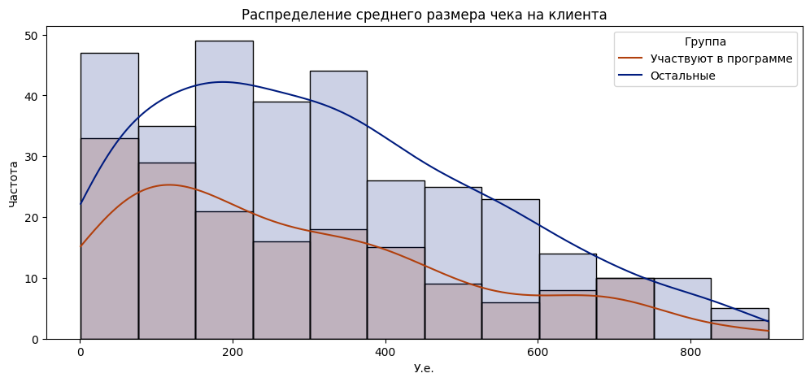

```python
# создаем график с размером 10x6 дюймов
fig, ax = plt.subplots(figsize=(12, 5))

# строим гистограмму с параметрами hue, title, legend, подписями по осям
sns.histplot(data=customer_mean_check, x="avg_check", hue="loyalty_program", kde=True, alpha=0.2, palette="dark")
plt.title("Распределение среднего размера чека на клиента")
plt.xlabel("У.е.")
plt.ylabel("Частота")
plt.legend(title="Группа", labels=['Участвуют в программе', 'Остальные'])
plt.show()
```

Распределение внутри наших групп является скошенным и не отвечает нормальному распределению. Ко всему прочему у нас выборки разных размеров и не зависят друг от друга.  
В таких вводных должен подойти критерий Манна-Уитни.

```python
# Генерируем две выборки
group_0  = customer_mean_check.query('loyalty_program==0')['avg_check']
group_1 = customer_mean_check.query('loyalty_program==1')['avg_check']

# Сравниваем выборки с помощью критерия Манна-Уитни
stat, p_value = mannwhitneyu(group_0, group_1)

# Выводим результаты
if p_value < 0.05:
    print('Получнный p-value равен {}. Нулевая гипотеза отвергнута. '.format(p_value))
    print('Альтернативная гипотеза принята: средний чек покупателей не входящих в группу участников программы лояльности больше чем у клиентов, входящих в нее')
elif p_value > 0.05:
    print('Получнный p-value равен {}. Нулевая гипотеза не отвергнута. Разницы в средних чеках между группами нет'.format(p_value))
```

```
Получнный p-value равен 0.042930779162402934. Нулевая гипотеза отвергнута.
Альтернативная гипотеза принята: средний чек покупателей не входящих в группу участников программы лояльности больше чем у клиентов, входящих в нее
```

### Проверка гипотезы о разнице в количестве позиций в чеке

```python
# Набор данных для анализа

customer_avg_position = (
    crd.groupby(['loyalty_program', 'customer_id'], as_index=False)
    .agg({'quantity':'count', 'purchase_id':'nunique'})
    .rename(columns={'quantity':'num_of_pos', 'purchase_id':'num_of_checks'})
)

customer_avg_position['avg_pos'] = round(customer_avg_position['num_of_pos'] / customer_avg_position['num_of_checks'], 2)

customer_avg_position
```

|  | loyalty_program | customer_id | num_of_pos | num_of_checks | avg_pos |
| --- | --- | --- | --- | --- | --- |
| 0 | 0 | 18027 | 4 | 1 | 4.0 |
| 1 | 0 | 18067 | 6 | 1 | 6.0 |
| 2 | 0 | 18072 | 2 | 1 | 2.0 |
| 3 | 0 | 18081 | 10 | 1 | 10.0 |
| 4 | 0 | 18116 | 3 | 1 | 3.0 |
| ... | ... | ... | ... | ... | ... |
| 479 | 1 | 23910 | 9 | 1 | 9.0 |
| 480 | 1 | 23918 | 2 | 1 | 2.0 |
| 481 | 1 | 23924 | 27 | 1 | 27.0 |
| 482 | 1 | 23936 | 1 | 1 | 1.0 |
| 483 | 1 | 23948 | 7 | 1 | 7.0 |

484 rows × 5 columns

Наши гипотезы звучат следующим образом:

**H0**: Разницы в среднем количестве позиций в чеках между группами нет  
**H1**: Среднее количество позиций в чеках покупателей не входящих в группу участников программы лояльности больше чем у клиентов, входящих в нее

Посмотрим распределение

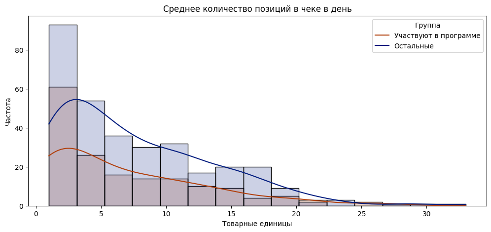

```python
# создаем график с размером 10x6 дюймов
fig, ax = plt.subplots(figsize=(12, 5))

# строим гистограмму с параметрами hue, title, legend, подписями по осям
sns.histplot(data=customer_avg_position, x="avg_pos", hue="loyalty_program", kde=True, alpha=0.2, palette="dark")
plt.title("Среднее количество позиций в чеке в день")
plt.xlabel("Товарные единицы")
plt.ylabel("Частота")
plt.legend(title="Группа", labels=['Участвуют в программе', 'Остальные'])
plt.show()
```

Распределение внутри наших групп является скошенным и не отвечает нормальному распределению. Ко всему прочему у нас выборки разных размеров и не зависят друг от друга.  
При таких вводных должен подойти критерий Манна-Уитни.

```python
# Генерируем две выборки
group_0  = customer_avg_position.query('loyalty_program==0')['avg_pos']
group_1 = customer_avg_position.query('loyalty_program==1')['avg_pos']

# Сравниваем выборки с помощью критерия Манна-Уитни
stat, p_value = mannwhitneyu(group_0, group_1)

# Выводим результаты
if p_value < 0.05:
    print('Получнный p-value равен {}. Нулевая гипотеза отвергнута.'.format(p_value))
    print('Альтернативная гипотеза принята: средний чек покупателей не входящих в группу участников программы лояльности больше чем у клиентов, входящих в нее')
elif p_value > 0.05:
    print('Получнный p-value равен {}. Нулевая гипотеза не отвергнута.'.format(p_value))
    print('Разницы в среднем количестве позиций в чеках между группами нет.')
```

```
Получнный p-value равен 0.09585842694324737. Нулевая гипотеза не отвергнута.
Разницы в среднем количестве позиций в чеках между группами нет.
```

## Общий вывод

**Анализ аудитории покупателей показал, что программа лояльности для покупателей не приносит плодов**.

```python
print('Согласно нашим данным, в группе участников программы средний чек даже ниже, чем у покупателей не входящих в эту группу')
print('Средний чек участников программы：{} ，средний чек остальных покупателей:{}'.format(group_mean_check['avg_check'][1],group_mean_check['avg_check'][0]))
print()
print('Другие косвенные показатели среди групп, которые себя не проявили и были приблизительно похожи, речь об:')
print('Среднее количество заказов участников программы {},  остальных покупателей:{}'.format(group_avg_orders['avg_orders'][1],group_avg_orders['avg_orders'][0]))
print('Среднее количество позиций чека участников программы {}, остальных покупателей:{}'.format(group_avg_position_a['avg_pos'][1],group_avg_position_a['avg_pos'][0]))
print('Средняя стоимость 1 единицы товара у участников программы {} у.е., остальных покупателей:{}'.format(avg_price_per_pos_a['avg_pos'][1],avg_price_per_pos_a['avg_pos'][0]))
```

```
Согласно нашим данным, в группе участников программы средний чек даже ниже, чем у покупателей не входящих в эту группу
Средний чек участников программы：283.26 ，средний чек остальных покупателей:319.43

Другие косвенные показатели среди групп, которые себя не проявили и были приблизительно похожи, речь об:
Среднее количество заказов участников программы 1.45,  остальных покупателей:1.4
Среднее количество позиций чека участников программы 6.27, остальных покупателей:7.08
Средняя стоимость 1 единицы товара у участников программы 3.94 у.е., остальных покупателей:3.78
```

**Рекомендации в связи с текущими показателями**

Можно рассмотреть несколько направлений работы:

- **увеличение покупаемых клиентом объемов товаров**

Например, вместо 1 единицы товара, под предлогом небольшой скидки, предложить купить 2 единицы

- **простимулировать клиентов чаще приобретать именно в вашем магазине**

Это можно обеспечить за счет работающей программы лояльности, делающей покупки выгодными, эксклюзивных товаров, акции

- **увеличить количество товарных позиций в чеке**

В это может помочь предложения сопутствующих товаров, выгодные подборки товаров с предложением скидок участникам программы лояльности